# 探索的データ分析（Exploratory Data Analysis）

H. Suzuki

2024年2月13日

# 1 ワークフロー

- 表題 Title
- 概要 Abstract
- データ情報：データ名、データコード、変数名、データ概要
- データの取得 - ダウンロードして保存しておく
  - 準備：`library(tidyverse); library(WDI)`
  - `df_w6eda <- WDI(indicator = c(co2pcap = "EN.ATM.CO2E.PC", forest = "AG.LND.FRST.ZS"), extra = TRUE)`
  - *二つ以上の指標、それぞれに変数名* `co2pcap`, `forest`
  - 追加情報：`extra = TRUE`; `region` 地域情報, `income` 収入レベル
  - データの確認：データが十分あるか、国名リスト、地域名リスト
- 分析する国のリスト：南部アフリカ関税同盟、国や地域を選択
- 分析・視覚化
  - 各年毎のデータの数の棒グラフ
  - 経年変化
    - 日本（身近な馴染みのあるデータを確認）
    - 南部アフリカ関税同盟、選択した国・地域
  - 分布
    - ヒストグラム（年を指定した度数分布）
    - 値が大きい10カ国とその値の棒グラフ
    - 値が小さい10カ国とその値の棒グラフ
  - 相関
    - 散布図（scatter plot）x-軸と、y-軸に、それぞれの変数をとる
    - 相関係数
- 各項目に、気づいたこと、疑問などを記録

# 2 準備

Posit.Cloud または RStudio で R を使うことを想定して説明と注意点を書きます。

## 2.1 R Notebook の作成

再現性と記録、さらには、コミュニケーションのために、R Notebook を作成します。R Notebook は、R Markdown の一形式です。

### 2.1.1 ファイルを作成するときの注意

1. Posit Cloud のときは、まず、Login し、プロジェクトに移動（クラスでは、[共有プロジェクト](https://posit.cloud/content/5539763) `intro2rj` を使用）のプロジェクトに入り、 ファイルから、ges001 のフォルダーを選択して、移動します。この中に、data フォルダが作成されていることを確認し、このges001 に、新しく作成したファイルを保存します。新しく作成したファイルの入っているフォルダーの中に、data フォルダがあることが大切です。そこに、データを書き込みます。
2. RStudio の場合には、まずは、新しい Project を作成します。File > New Project から作成します。すでに、作成してある場合は、それを、Open Project や、Recent Project から開きます。その中に、新しいファイルを作成します。作成したフォルダーに、data フォルダがあることを確認してください。新しく作成したファイルの入っているフォルダーの中に、data フォルダがあることが大切です。そこに、データを書き込みます。
- Rmd ファイルを作成したら、すぐに、ID と名前を書きます。タイトルも決まっていたら書きます。

### 2.1.2 ファイルを提出するときの注意

#### 2.1.2.1 確認作業

- Run All で、最後に、もう一度、すべてを、実行。
- エラーが修正できない場合には、その次のコードチャンクから、Run Below で実行。
- Preview の右のギアマークから、Preview in Widow を選択し、View in Browser で、いつも、使っている、Web Browser で、最後まで、グラフなどが出ているか確認。

#### 2.1.2.2 Posit.Cloud のファイルダウンロード

RStudio の場合には、自分の PC に作成したファイルがありますから、問題ないと思いますが、Posit Cloud で作成した場合には、自分の PC にダウンロードする必要があります。

提出したいファイルの左にあるチェックボックスをチェックします。Files の 右端にある、ギアマークの Export を押すと、ダウンロードできます。それを提出してください。末尾が、nb.html となっているものを提出していただくのがよいですが、よくわからないときは、nb.html ファイルと、Rmd ファイルと両方提出してください。

## 2.2 必要なパッケージの読み込み

このコースでは、この二つのパッケージ（R の機能を拡張するもの）を読み込みます。初めて使う時は、Tools > Install Packages からインストールします。

```r
library(tidyverse)
library(WDI)
```

# 3 データ

- 世界開発指標（World Development Indicators）[Link](https://datatopics.worldbank.org/world-development-indicators/) からデータを選択します。
- 授業で使ったデータのリスト：[リンク](https://ds-sl.github.io/intro2r/ges001/ges001data.nb.html)

## 3.1 データ情報

データ名、データID（WDI コード）、データ概要を取得して書きます。

リンクを残しておくとあとで便利です。サイトの Details に概要も、データ ID もあります。日本語にしておくのも良いでしょう。

このときに、短い変数名も決めておきます。

### 3.1.1 例

データ１：一人当たりの二酸化炭素排出量（トン）CO2 emissions (metric tons per capita) ：EN.ATM.CO2E.PC [[Link](https://data.worldbank.org/indicator/EN.ATM.CO2E.PC)]

データ１変数名：co2

データ１概要：Carbon dioxide emissions are those stemming from the burning of fossil fuels and the manufacture of cement. They include carbon dioxide produced during consumption of solid, liquid, and gas fuels and gas flaring.

データ２：化石燃料での電気生成の割合（%）Electricity production from oil, gas and coal sources (% of total)：EG.ELC.FOSL.ZS [[Link](https://data.worldbank.org/indicator/EG.ELC.FOSL.ZS)]

データ２変数名：fossil

データ２概要：Sources of electricity refer to the inputs used to generate electricity. Oil refers to crude oil and petroleum products. Gas refers to natural gas but excludes natural gas liquids. Coal refers to all coal and brown coal, both primary (including hard coal and lignite-brown coal) and derived fuels (including patent fuel, coke oven coke, gas coke, coke oven gas, and blast furnace gas). Peat is also included in this category.

## 3.2 データの読み込み（Importing）

WDI で読み込みます。

- 読み込むときには、指標 ID と、変数名が必要です。
- 読み込んだデータに名前をつけます。

### 3.2.1 例

この例では、二つの指標を、読み込みます。

```r
df_co2_fossil <- WDI(indicator = c(co2 = "EN.ATM.CO2E.PC",
                     fossil = "EG.ELC.FOSL.ZS"), extra = TRUE)
df_co2_fossil
```

- 一つ目のデータの指標（ID）は、EN.ATM.CO2E.PC、変数名は、co2 にしました。二つ目のデータの指標（ID）は、EG.ELC.FOSL.ZS、変数名は、fossil にしました。
- 指標 (ID) は WDI のサイトから得たものを使わなければいけませんが、変数名は自分で決められます。 できるだけ、分かりやすい名前にしておくのが良いでしょう。データ名と、変数名を区別する為、わたしは、データは、df_ で始まる名前にしています。
- 最後にextra = TRUE としておくと、国ごとの地域、所得レベルなどの情報を一緒に読み込んでくれます。必要がなければ、次のようになります。

```r
df_co2_fossil_short <- WDI(indicator = c(co2 = "EN.ATM.CO2E.PC",
                     fossil = "EG.ELC.FOSL.ZS"))
df_co2_fossil_short
```

-「機械は思った通りに動かない。書いた通りに動く。」と言われます。引用符や、かっこなど、マッチするように、書いてください。

### 3.2.2 WDI でのデータの読み込みのコードについて

実は、次の命令でも、データをとってきます。

```r
WDI()
```

| country | iso2c | iso3c | year | NY.GDP.PCAP.KD |
| --- | --- | --- | --- | --- |
| Africa Eastern and Southern | ZH | AFE | 2022 | 1487.4764 |
| Africa Eastern and Southern | ZH | AFE | 2021 | 1474.6577 |
| Africa Eastern and Southern | ZH | AFE | 2020 | 1450.7215 |
| Africa Eastern and Southern | ZH | AFE | 2019 | 1532.4689 |
| Africa Eastern and Southern | ZH | AFE | 2018 | 1542.2385 |
| Africa Eastern and Southern | ZH | AFE | 2017 | 1545.2031 |
| Africa Eastern and Southern | ZH | AFE | 2016 | 1546.4645 |
| Africa Eastern and Southern | ZH | AFE | 2015 | 1554.1673 |
| Africa Eastern and Southern | ZH | AFE | 2014 | 1551.7149 |
| Africa Eastern and Southern | ZH | AFE | 2013 | 1533.3256 |

[output cut: 990 more lines]

Help をみると次のように書かれています。

```
WDI(
  country = "all",
  indicator = "NY.GDP.PCAP.KD",
  start = 1960,
  end = NULL,
  extra = FALSE,
  cache = NULL,
  latest = NULL,
  language = "en"
)
```

これらの変数を指定できますが、右にあるのが、初期値です。一つ一つの説明も、Help ページに書いてあります。

## 3.3 データの保存

ダウンロードしたデータは、data フォルダに保存しておくことをお勧めします。世界銀行は、ときどき、データをアップデータするために、サービスが停止することがあります。また、保存したものを読み込むことで、毎回ダウンロードしないで済むメリットもあります。

### 3.3.1 例

読み込んだデータ df_co2_fossil を、CSV（カンマ区切り形式）で、data フォルダーの中に、co2_fossil.csv という名前で保存します。このときに、data フォールだがないと、保存できません。R Notebook があるフォルダーの中に、data フォルダがあることが必要です。data フォルダがないというエラーメッセージが出たら、最初に説明した、ファイルを作る時の部分を読み返してください。間違っていたら、ここで、Save as で適切なところに、保存しなおしてください。

```r
write_csv(df_co2_fossil, "data/co2_fossil.csv")
```

```r
df_co2_fossil <- read_csv("data/co2_fossil.csv")
```

```r
write_csv(df_co2_fossil_short, "data/co2_fossil_short.csv")
```

```r
df_co2_fossil_short <- read_csv("data/co2_fossil_short.csv")
```

## 3.4 データの確認

データを確認します。どのような列（変数）があるかを確認しますが、特に、最初に定めた、指標の変数が、ある列にはっていることを確認することも大切です。特に、extra = TRUE として読み込むと、さまざまな変数を読み込んでいますから、確認してください。

### 3.4.1 例

データ全体の確認。右上の三角印から、隠れている変数をみることができ、下の NEXT や、番号から、次のページへと移動し、10データずつ確認できるようになっています。

head(df_co2_fossil) とすると、最初の６行だけ、tail(df_co2_fossil) とすると、最後の、6行を確認することができます。

```r
df_co2_fossil
```

| country | iso2c | iso3c | year | status | lastupdated | co2 | fossil | region | capital | longitude | latitude | income | lending |
| --- | --- | --- | --- | --- | --- | --- | --- | --- | --- | --- | --- | --- | --- |
| Afghanistan | AF | AFG | 2014 | NA | 2023-12-19 | 0.28369240 | NA | South Asia | Kabul | 69.17610 | 34.52280 | Low income | IDA |
| Afghanistan | AF | AFG | 1971 | NA | 2023-12-19 | NA | NA | South Asia | Kabul | 69.17610 | 34.52280 | Low income | IDA |
| Afghanistan | AF | AFG | 2006 | NA | 2023-12-19 | 0.08975691 | NA | South Asia | Kabul | 69.17610 | 34.52280 | Low income | IDA |
| Afghanistan | AF | AFG | 2013 | NA | 2023-12-19 | 0.29808781 | NA | South Asia | Kabul | 69.17610 | 34.52280 | Low income | IDA |
| Afghanistan | AF | AFG | 1995 | NA | 2023-12-19 | 0.08878116 | NA | South Asia | Kabul | 69.17610 | 34.52280 | Low income | IDA |
| Afghanistan | AF | AFG | 2005 | NA | 2023-12-19 | 0.08036113 | NA | South Asia | Kabul | 69.17610 | 34.52280 | Low income | IDA |
| Afghanistan | AF | AFG | 1997 | NA | 2023-12-19 | 0.07555870 | NA | South Asia | Kabul | 69.17610 | 34.52280 | Low income | IDA |
| Afghanistan | AF | AFG | 1998 | NA | 2023-12-19 | 0.07126970 | NA | South Asia | Kabul | 69.17610 | 34.52280 | Low income | IDA |
| Afghanistan | AF | AFG | 1999 | NA | 2023-12-19 | 0.05824684 | NA | South Asia | Kabul | 69.17610 | 34.52280 | Low income | IDA |
| Afghanistan | AF | AFG | 1996 | NA | 2023-12-19 | 0.08226652 | NA | South Asia | Kabul | 69.17610 | 34.52280 | Low income | IDA |

[output cut: 990 more lines]

データの変数（列）の確認には、str() も便利です。下のコードは、df_co2_fossil |> str() としても同じです。|> はパイプオペレータと呼ばれます。かっこの中の第一引数として、一つ前の出力を代入します。

```r
str(df_co2_fossil)
```

```
spc_tbl_ [16,758 × 14] (S3: spec_tbl_df/tbl_df/tbl/data.frame)
 $ country    : chr [1:16758] "Afghanistan" "Afghanistan" "Afghanistan" "Afghanistan" ...
 $ iso2c      : chr [1:16758] "AF" "AF" "AF" "AF" ...
 $ iso3c      : chr [1:16758] "AFG" "AFG" "AFG" "AFG" ...
 $ year       : num [1:16758] 2014 1971 2006 2013 1995 ...
 $ status     : logi [1:16758] NA NA NA NA NA NA ...
 $ lastupdated: Date[1:16758], format: "2023-12-19" "2023-12-19" ...
 $ co2        : num [1:16758] 0.2837 NA 0.0898 0.2981 0.0888 ...
 $ fossil     : num [1:16758] NA NA NA NA NA NA NA NA NA NA ...
 $ region     : chr [1:16758] "South Asia" "South Asia" "South Asia" "South Asia" ...
 $ capital    : chr [1:16758] "Kabul" "Kabul" "Kabul" "Kabul" ...
 $ longitude  : num [1:16758] 69.2 69.2 69.2 69.2 69.2 ...
 $ latitude   : num [1:16758] 34.5 34.5 34.5 34.5 34.5 ...
 $ income     : chr [1:16758] "Low income" "Low income" "Low income" "Low income" ...
 $ lending    : chr [1:16758] "IDA" "IDA" "IDA" "IDA" ...
 - attr(*, "spec")=
  .. cols(
  ..   country = col_character(),
  ..   iso2c = col_character(),
  ..   iso3c = col_character(),
  ..   year = col_double(),
  ..   status = col_logical(),
  ..   lastupdated = col_date(format = ""),
  ..   co2 = col_double(),
  ..   fossil = col_double(),
  ..   region = col_character(),
  ..   capital = col_character(),
  ..   longitude = col_double(),
  ..   latitude = col_double(),
  ..   income = col_character(),
  ..   lending = col_character()
  .. )
 - attr(*, "problems")=<externalptr>
```

## 3.5 各年毎のデータの数の棒グラフ

世界銀行では、1960年から昨年までのデータを作成していますが、すべてあるわけではありません。また、国や地域によっては、データがない場合があります。最新のデータは何年のものかも含めて、調べておく必要があります。

### 3.5.1 例

この棒グラフでは、1990年から2015年までのデータが180程度、すなわち、180の国の地域については、両方の知っ方についてのデータがあることがわかります。

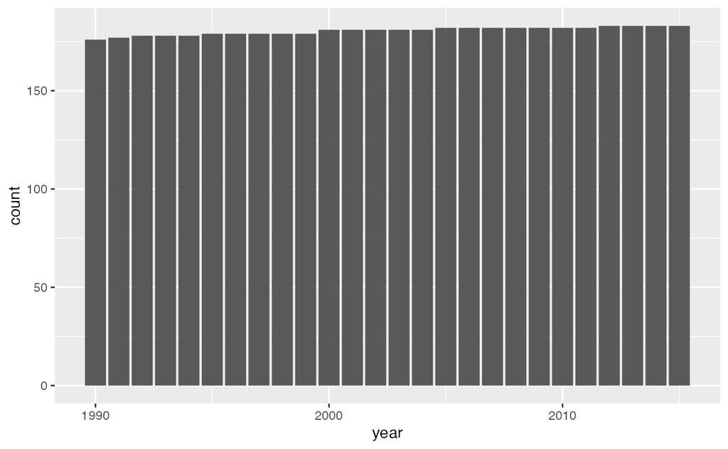

```r
df_co2_fossil |> drop_na(co2, fossil) |>
  ggplot(aes(year)) + geom_bar()
```

各、変数ごとに調べたい時は、long table を使います。少し高級ですね。

この例では、fossil のデータは、1960 年からありますが、co2 は、1990 年から。また、co2 は、2020 年までのデータがありますが、fossil は、2015 年までのデータしかないことがわかります。

pivot_longer(c(co2, fossil)) では、これら二つの指標を、name という変数に、それぞれの値は、value に入れます。縦長のデータということで、説明しました。（演習7）

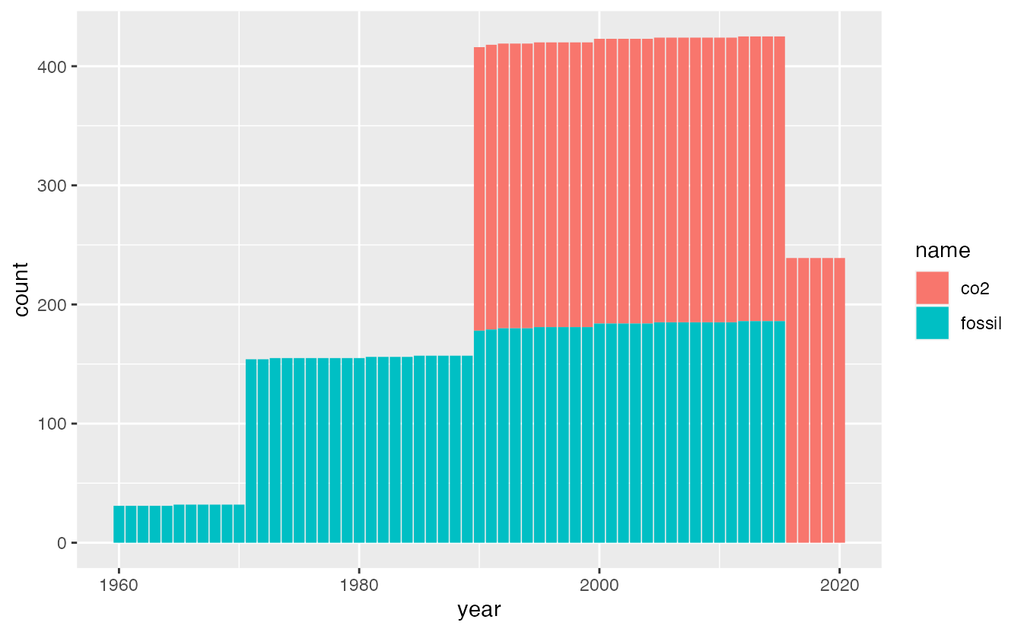

```r
df_co2_fossil |> pivot_longer(c(co2, fossil)) |> drop_na(value) |>
  ggplot(aes(year, fill = name)) + geom_bar()
```

# 4 変形（transforming）

データの必要な部分だけを取り出して、分析します。

## 4.1 基本的な変形

- **行の選択**：`filter(country %in% c("Japan", "China"))`, `distinct(country)`, `drop_na(value)`
- **列の選択**：`select(country, iso2c, year, var1, var2, region)`

## 4.2 縦長データ・横長データ

- **横並びの変数を縦並びに**：name 列と、value 列を作り、var_1, var_2, … , var_n を name 列に、対応する値を value 列に
  - `pivot_longer(cols = c(var_1, var_2, ... , var_n))`
  - `pivot_longer(cols = c(female_unemploy, male_unemploy))`
  - `pivot_longer(c(electricity_urban, electricity_rural))`: `cols =` は省略可能
  - `pivot_longer(cols = electricity_urban:sanitation_rural))`：electricity_urban の列から、sanitation_rural の列までのすべての変数を指定
- **活用：**`pivot_longer(cols = c(var1, var2))|> ggplot(aes(year, value, col = name) + geom_line()`
- **縦並びの変数を横並びに**：列名を指定する変数と、値の変数を指定し、横並びにします。
  - `pivot_wider(names_from = var1, values_from = var2)
  - `pivot_wider(names_from = name, values_from = value): pivot_longer の逆です。

## 4.3 変数の選択（selecting）

extra = TRUE として、データを入手すると、使わない変数もたくさんあるので、見やすいように、必要な変数だけにします。必要なものを、落とさないように、気をつけます。

### 4.3.1 例

わたしは、少し短めの名前を使っています。結果を、すぐ表示するようにして、そこで、必要な変数が、のこていることを確認します。

```r
df_co2fos <- df_co2_fossil |>
  select(country, iso2c, year, co2, fossil, region, income)
df_co2fos
```

| country | iso2c | year | co2 | fossil | region | income |
| --- | --- | --- | --- | --- | --- | --- |
| Afghanistan | AF | 2014 | 0.28369240 | NA | South Asia | Low income |
| Afghanistan | AF | 1971 | NA | NA | South Asia | Low income |
| Afghanistan | AF | 2006 | 0.08975691 | NA | South Asia | Low income |
| Afghanistan | AF | 2013 | 0.29808781 | NA | South Asia | Low income |
| Afghanistan | AF | 1995 | 0.08878116 | NA | South Asia | Low income |
| Afghanistan | AF | 2005 | 0.08036113 | NA | South Asia | Low income |
| Afghanistan | AF | 1997 | 0.07555870 | NA | South Asia | Low income |
| Afghanistan | AF | 1998 | 0.07126970 | NA | South Asia | Low income |
| Afghanistan | AF | 1999 | 0.05824684 | NA | South Asia | Low income |
| Afghanistan | AF | 1996 | 0.08226652 | NA | South Asia | Low income |

[output cut: 990 more lines]

## 4.4 縦長の表（Long Table）に変換

上の説明を、確認してください。たいせつなのは、これをどのように活用するかですから、このあとに、df_co2fos_long を使って、図を描いているものを、確認して、df_co2fos との違いを比較してください。このあとも、df_co2fos を使って描画をしている場合もあります。どちらでも、使えるものと、一方を使うと、他方を使うのと比較して、非常に、単純になる場合があることを確認していってください。

### 4.4.1 例

*`co2` と `fossil` の列（変数）を、変数を name に、値を value に入れて、縦に並べます。*

```r
df_co2fos_long <- df_co2fos |>
  pivot_longer(cols = c(co2,fossil))
df_co2fos_long
```

| country | iso2c | year | region | income | name | value |
| --- | --- | --- | --- | --- | --- | --- |
| Afghanistan | AF | 2014 | South Asia | Low income | co2 | 0.28369240 |
| Afghanistan | AF | 2014 | South Asia | Low income | fossil | NA |
| Afghanistan | AF | 1971 | South Asia | Low income | co2 | NA |
| Afghanistan | AF | 1971 | South Asia | Low income | fossil | NA |
| Afghanistan | AF | 2006 | South Asia | Low income | co2 | 0.08975691 |
| Afghanistan | AF | 2006 | South Asia | Low income | fossil | NA |
| Afghanistan | AF | 2013 | South Asia | Low income | co2 | 0.29808781 |
| Afghanistan | AF | 2013 | South Asia | Low income | fossil | NA |
| Afghanistan | AF | 1995 | South Asia | Low income | co2 | 0.08878116 |
| Afghanistan | AF | 1995 | South Asia | Low income | fossil | NA |

[output cut: 990 more lines]

## 4.5 国と地域

主として分析する国や地域のリストを作成します。最初に書いてありますが、このあとの分析で、国や、地域を加えたり、変更することもあるでしょう。全体の構成としては、視覚化などを始める前に、リストを作成しておくことが必要です。定義がされていないと、エラーが生じるからです。最後に、Run All などをすればわかりますが、上から順に実行するので、たとえば、ASEAN などの分析をするときに、それが、最初の方で定義されていなければ、エラーとなります。途中では、その都度定義すれば、それを、理解して実行しますが、完成形にするときには、実際に使うコードより前に定義しておかないといけません。

国や地域を選択するには、国名 country または、iso2c などの国のコードが必要です。正確でないといけませんし、iso2c などをすべて覚えているわけではないので、それらを表示させ、そこから、コピー・ペーストするのが安全です。

国名は一般的に長いので、iso2c も便利です。指定する時は、たとえば、asean に国名が、ASEAN に iso2c コードが入っていれば、

- `filter(country %in$ asean)`
- `filter(iso2c %in% ASEAN)`

選択するときの、条件が変わりますから、注意してください。

### 4.5.1 地域の `iso2c` コード

country には、国と地域両方が入っています。地域の iso2c は以下のものです。国と地域を区別するときに使います。

! は否定です。

```r
REGION <- c("1A", "1W", "4E", "6F", "6N", "6X", "7E", "8S", "A4", "A5",
"A9", "B1", "B2", "B3", "B4", "B6", "B7", "B8", "C4", "C5", "C6",
"C7", "C8", "C9", "D2", "D3", "D4", "D5", "D6", "D7", "EU", "F1",
"F6", "M1", "M2", "N6", "OE", "R6", "S1", "S2", "S3", "S4", "T2",
"T3", "T4", "T5", "T6", "T7", "V1", "V2", "V3", "V4", "XC", "XD",
"XE", "XF", "XG", "XH", "XI", "XJ", "XL", "XM", "XN", "XO", "XP",
"XQ", "XT", "XU", "XY", "Z4", "Z7", "ZB", "ZF", "ZG", "ZH", "ZI",
"ZJ", "ZQ", "ZT")
```

#### 4.5.1.1 地域のリストを表示

```r
df_co2fos |> filter(iso2c %in% REGION) |> distinct(country, iso2c)
```

#### 4.5.1.2 国名とその地域・所得レベルを表示

df_co2_fossil とそれから変数を選択した、df_co2fos は、extra=TRUE として、追加情報がありますから、地域情報（region）と 所得レベル（income）も加えておきます。

```r
df_co2fos |> filter(!(iso2c %in% REGION)) |> distinct(country, iso2c,region,income)
```

| country | iso2c | region | income |
| --- | --- | --- | --- |
| Afghanistan | AF | South Asia | Low income |
| Albania | AL | Europe & Central Asia | Upper middle income |
| Algeria | DZ | Middle East & North Africa | Lower middle income |
| American Samoa | AS | East Asia & Pacific | Upper middle income |
| Andorra | AD | Europe & Central Asia | High income |
| Angola | AO | Sub-Saharan Africa | Lower middle income |
| Antigua and Barbuda | AG | Latin America & Caribbean | High income |
| Argentina | AR | Latin America & Caribbean | Upper middle income |
| Armenia | AM | Europe & Central Asia | Upper middle income |
| Aruba | AW | Latin America & Caribbean | High income |

[output cut: 207 more lines]

df_co2_fossil_short では、extra=TRUE は指定せず（初期設定通り extra = FALSE）としてありますから、上の、df_co2fos を、df_co2_fossil_short に置き換えるとエラーが出ます。region や、income の列がないからです。その場合は、次のようにします。

```r
df_co2_fossil_short |> filter(!(iso2c %in% REGION)) |> distinct(country, iso2c)
```

| country | iso2c |
| --- | --- |
| Afghanistan | AF |
| Albania | AL |
| Algeria | DZ |
| American Samoa | AS |
| Andorra | AD |
| Angola | AO |
| Antigua and Barbuda | AG |
| Argentina | AR |
| Armenia | AM |
| Aruba | AW |

[output cut: 207 more lines]

存在しない変数についてなにかをしようとすると Error になります。そのときは、そこで使っているデータに実際に、その変数があるかどうか確認してください。この場合なら、以下のようにすれば、region や、income という変数がないことは確認できますね。

```r
df_co2_fossil_short
```

| country | iso2c | iso3c | year | co2 | fossil |
| --- | --- | --- | --- | --- | --- |
| Afghanistan | AF | AFG | 1960 | NA | NA |
| Afghanistan | AF | AFG | 1961 | NA | NA |
| Afghanistan | AF | AFG | 1962 | NA | NA |
| Afghanistan | AF | AFG | 1963 | NA | NA |
| Afghanistan | AF | AFG | 1964 | NA | NA |
| Afghanistan | AF | AFG | 1965 | NA | NA |
| Afghanistan | AF | AFG | 1966 | NA | NA |
| Afghanistan | AF | AFG | 1967 | NA | NA |
| Afghanistan | AF | AFG | 1968 | NA | NA |
| Afghanistan | AF | AFG | 1969 | NA | NA |

[output cut: 990 more lines]

### 4.5.2 国や地域の選択

授業で紹介したものを次に書いておきます。

```r
asean <- c("Brunei Darussalam", "Cambodia", "Indonesia", "Lao PDR", "Malaysia",
"Myanmar", "Philippines", "Singapore", "Viet Nam")
```

```r
ASEAN <- c("BN", "KH", "ID", "LA", "MY", "MM", "PH", "SG", "VN")
```

```r
BRICS <- c("Brazil", "Russian Federation", "India", "China", "South Africa")
```

```r
SACU <- c("South Africa", "Namibia", "Eswatini", "Botswana", "Lesotho")
```

```r
LA_GINI <- c("Suriname", "Belize", "Brazil", "Colombia")
```

### 4.5.3 地域（region）と、所得レベル

extra = TRUE として、データを入手すると、地域名と、所得レベルも一緒に得られます。それらは、どのようなものか確認してみます。distinct(region) は、異なるもののみ取得、pull() は、表形式ではなく、ベクトル（データのならび）で取得する為に使っています。

```r
df_co2fos |> distinct(region) |> pull()
```

```
[1] "South Asia"                 "Aggregates"
[3] "Europe & Central Asia"      "Middle East & North Africa"
[5] "East Asia & Pacific"        "Sub-Saharan Africa"
[7] "Latin America & Caribbean"  "North America"
[9] NA
```

これも、定義しておきます。REGION はすでに使ってありますから、混乱をさけるため、小文字にしました。

```r
regions <- c("South Asia", "Europe & Central Asia", "Middle East & North Africa",
"East Asia & Pacific", "Sub-Saharan Africa", "Latin America & Caribbean",
"North America")
```

```r
df_co2fos |> distinct(income) |> pull()
```

```
[1] "Low income"          "Aggregates"          "Upper middle income"
[4] "Lower middle income" "High income"         NA
[7] "Not classified"
```

こちらは、ある程度順番も重要ですから、次のようにしておきます。

```r
INCOME <- c("High income", "Upper middle income", "Lower middle income",
"Low income")
```

### 4.5.4 分析する国や地域のリスト

あなたが分析したい国や地域のリストをまずは書いておくと、思いつきで変更するのではなく、首尾一貫した分析ができます。

最初の確認のためには、わたしは、Japan (iso2c では、JP) か、World (iso2c では、1W) をつかうことにしています。身近な、または、全体から始める為です。分析を始めたら、CHOSEN_COUNTRIES は変更した方が良い場合もありますし、CHOSEN_COUNTRIES_1, CHOSEN_COUNTRIES_2 などとして、幾つものグループについて分析するのもよいでしょう。もっと短い名前にしてもよいですが、途中まで、入力すればあとは自動的に表示されますから、矢印と、Tab を使えば、簡単に入力できます。

```
CHOSEN_COUNTRY <- ""
CHOSEN_COUNTRIES <- c()
```

# 5 分析・視覚化

## 5.1 さまざまな視覚化（Visualizing）

例として、中心的に使うデータは、二つです。

- df_co2fos: co2 (Co2 per Capita) の値と、化石燃料による発電の割合を表す fossil が変数に含まれ、year 以外に、region や、income のデータも入っています。
- df_co2fos_long: 縦長の表で、name に、co2 と fossil を含み、value に その値が入っています。データをよく確認してください。上の方にあります。

基本的には、データを絞り込み、そのあとで、ggplot2 を使います。以下のようなフォーマットになります。

```
df_co2fos |> filter などで必要な行を絞り込む　|> drop_na(変数) などで、NA を削除 |>
  ggplot(aes(x, y)) + geom_***()
```

aes() の部分を mapping と言います。実は、`mapping = aes(x, y)` の mapping を省略しています。詳細は、geom_***() のいろいろな描写方法によって異なりますので、それぞれの、Help を確認してください。

## 5.2 経年変化

year を x 軸に、変数の値を y 軸に取ると、経年変化がわかります。日本や、世界でみてみます。drop_na(var) を使うことで、空白部分がなくなり、Warning も減りますが、違う指標を比較する時は、これを入れないのも手ですし、同じ基準にするために、drop_na(var1, var2) としておく手もあります。

一つの国・地域

```
df_co2_fos |> filter(country == "国名") |> drop_na(変数) |>
  ggplot(aes(year, 変数)) + geom_line()
```

いくつかの国・地域

```
df_co2_fos |> filter(country %in% c("国名1", "国名2", ... , "国名n")) |> drop_na(変数) |>
  ggplot(aes(year, 変数, col = country)) + geom_line()
```

iso2c で、国・地域を選択することも可能です。

```
df_co2_fos |> filter(iso2c %in% c("二文字コード1", "二文字コード2", ... , "二文字コードn")) |>
  drop_na(変数) |>
  ggplot(aes(year, 変数, col = country)) + geom_line()
```

最初分析中は、省略してもよいですが、なるべく、

- labs(title = “グラフのタイトル”)

として、タイトル名を入れましょう。x 軸、y 軸のラベルを変更する時は、

- labs(title = “グラフのタイトル”, x = “年”, y = “変数の名前”)

とします。

### 5.2.1 例

#### 5.2.1.1 国または地域の一つの変数に関する経年変化

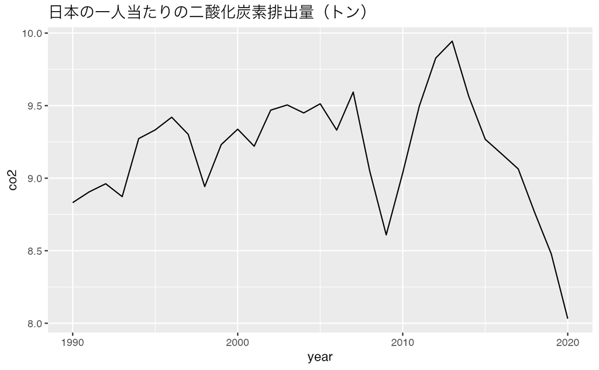

```r
df_co2fos |> filter(country == "Japan") |> drop_na(co2) |>
  ggplot(aes(year, co2)) + geom_line() + labs(title = "日本の一人当たりの二酸化炭素排出量（トン）")
```

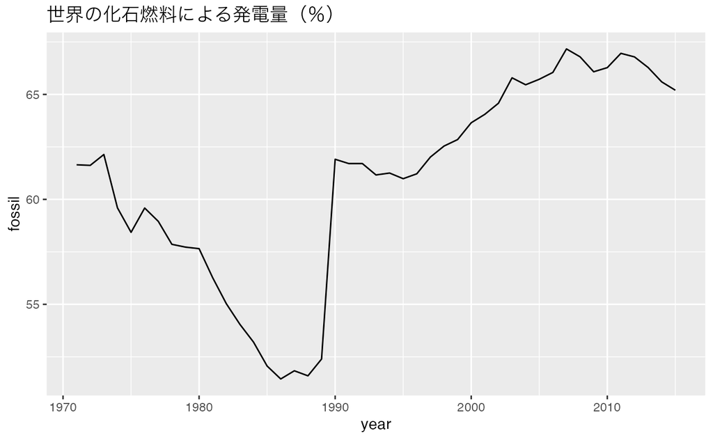

```r
df_co2fos |> filter(country == "World") |> drop_na(fossil) |>
  ggplot(aes(year, fossil)) + geom_line() + labs(title = "世界の化石燃料による発電量（％）")
```

ここでは、日本と世界と変えましたが、同じ国または地域で比較するのが適切でしょう。いくつもの国や、地域でみてみることはおすすめです。

#### 5.2.1.2 国または地域の二つ以上の変数に関する経年変化

このためには、縦長の表を使います。

ただ、この例では、二つの指標の単位がことなるため、このように表示するのが適切かどうかは不明です。

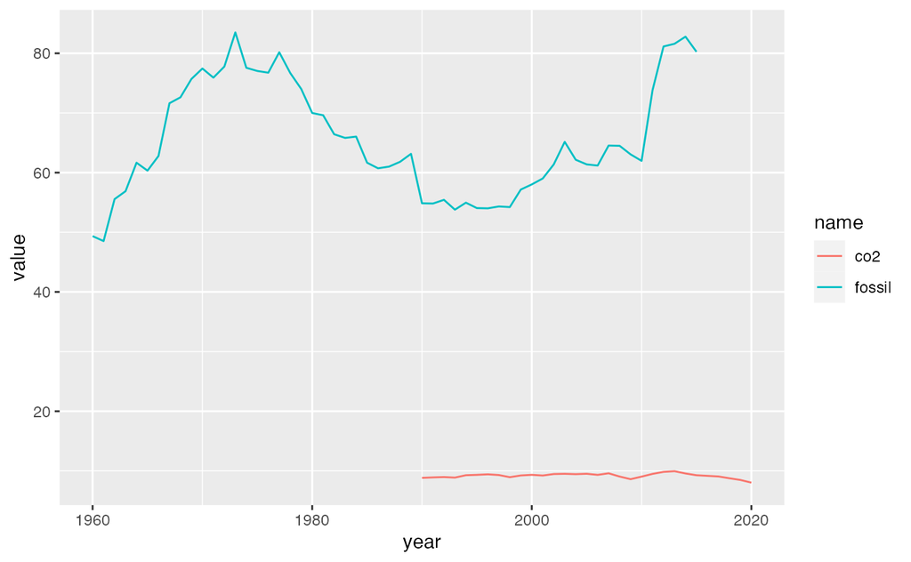

```r
df_co2fos_long |> filter(country == "Japan") |> drop_na(value) |>
  ggplot(aes(year, value, col = name)) + geom_line()
```

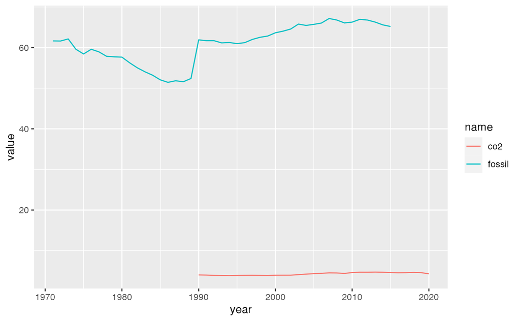

```r
df_co2fos_long |> filter(country == "World") |> drop_na(value) |>
  ggplot(aes(year, value, col = name)) + geom_line()
```

#### 5.2.1.3 データの確認

グラフが表示されなかったり、期待したものではない時はそのデータを見てみましょう。 途中から、co2 と fossil の両方のデータがあることがわかります。上の方で、各年のデータの数の棒グラフでも一般的傾向を確認してありますね。

```r
df_co2fos_long |> filter(country == "Japan") |> drop_na(value)
```

| country | iso2c | year | region | income | name | value |
| --- | --- | --- | --- | --- | --- | --- |
| Japan | JP | 1983 | East Asia & Pacific | High income | fossil | 65.819542 |
| Japan | JP | 1967 | East Asia & Pacific | High income | fossil | 71.630769 |
| Japan | JP | 1969 | East Asia & Pacific | High income | fossil | 75.695438 |
| Japan | JP | 1972 | East Asia & Pacific | High income | fossil | 77.777778 |
| Japan | JP | 1968 | East Asia & Pacific | High income | fossil | 72.623644 |
| Japan | JP | 1962 | East Asia & Pacific | High income | fossil | 55.555556 |
| Japan | JP | 1970 | East Asia & Pacific | High income | fossil | 77.452086 |
| Japan | JP | 1966 | East Asia & Pacific | High income | fossil | 62.787992 |
| Japan | JP | 1977 | East Asia & Pacific | High income | fossil | 80.178929 |
| Japan | JP | 1978 | East Asia & Pacific | High income | fossil | 76.700157 |

[output cut: 77 more lines]

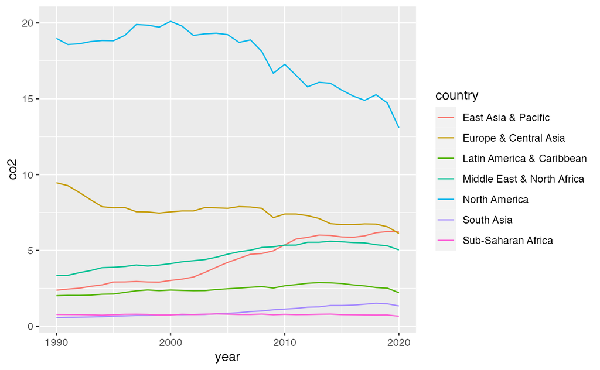

```r
df_co2fos |> filter(country %in% regions) |> drop_na(co2) |>
  ggplot(aes(year, co2, col = country)) + geom_line()
```

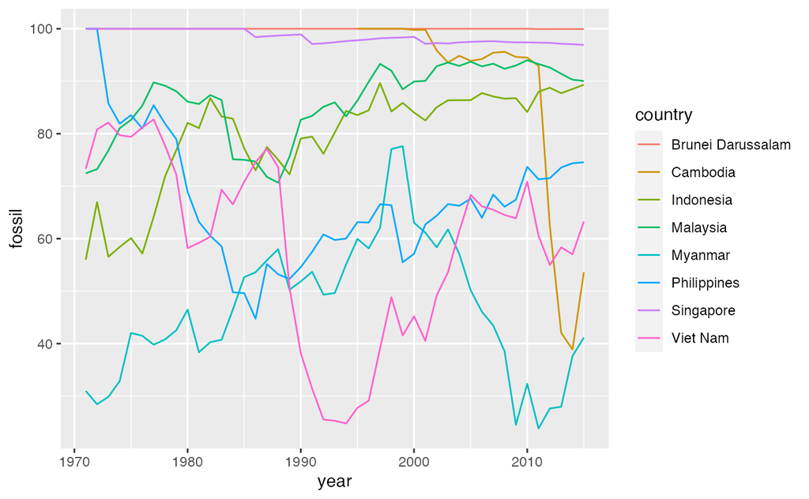

```r
df_co2fos |> filter(iso2c %in% ASEAN) |> drop_na(fossil) |>
  ggplot(aes(year, fossil, col = country)) + geom_line()
```

#### 5.2.1.5 いくつかの国または地域の二つ以上の変数に関する経年変化

上にも書いたように、単位が異なるので、適切かは疑問ですが、同時にみることはできます。

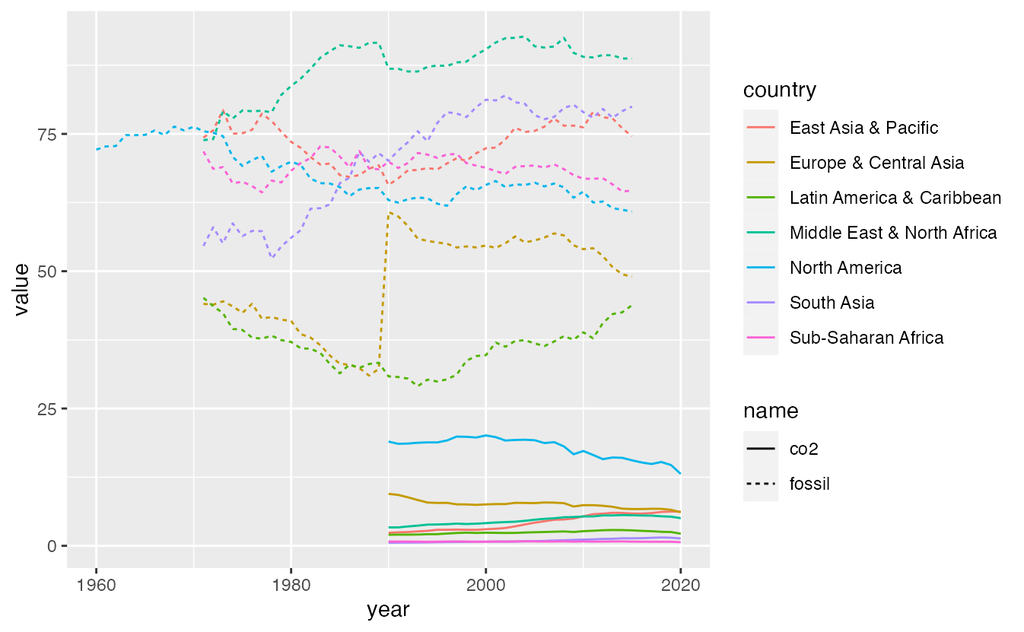

```r
df_co2fos_long |> filter(country %in% regions) |> drop_na(value) |>
  ggplot(aes(year, value, col = country, linetype = name)) + geom_line()
```

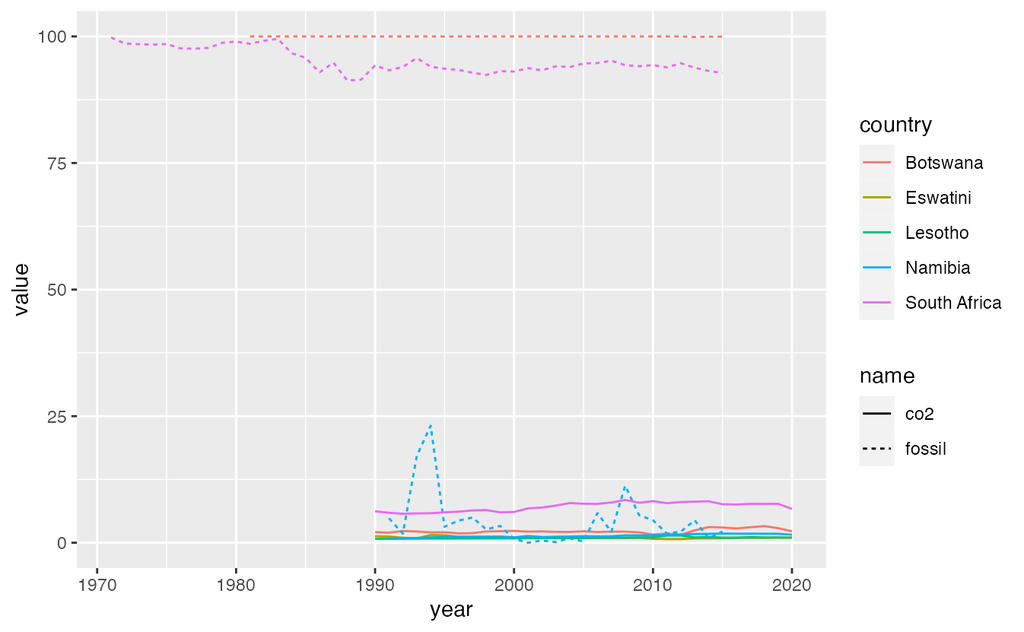

```r
df_co2fos_long |> filter(country %in% SACU) |> drop_na(value) |>
  ggplot(aes(year, value, col = country, linetype = name)) + geom_line()
```

## 5.3 分布

それぞれの指標の分布をみます。比較するには、箱ひげ図も有効です。

### 5.3.1 ヒストグラム

bins 区分けの数、binwidth 区分幅を変更して、適切に表示されるようにします。何も書いていないと、初期設定では、bins = 30 になっています。

#### 5.3.1.1 例

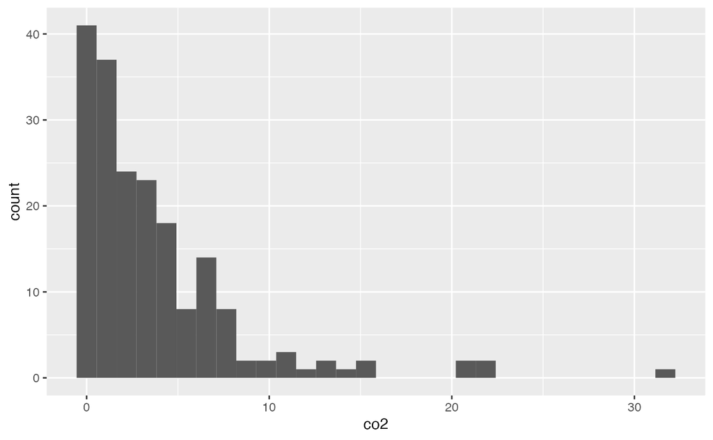

```r
df_co2fos |> filter(!(iso2c %in% REGION)) |> filter(year == 2020) |> drop_na(co2) |>
  ggplot(aes(co2)) + geom_histogram()
```

bins = 10 に変更すると次のようになります。

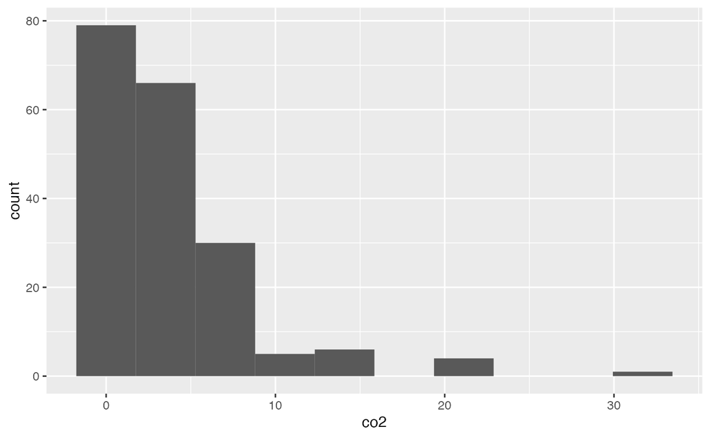

```r
df_co2fos |> filter(!(iso2c %in% REGION)) |> filter(year == 2020) |> drop_na(co2) |>
  ggplot(aes(co2)) + geom_histogram(bins = 10)
```

binwidth = 2 とすると下のようなグラフになります。

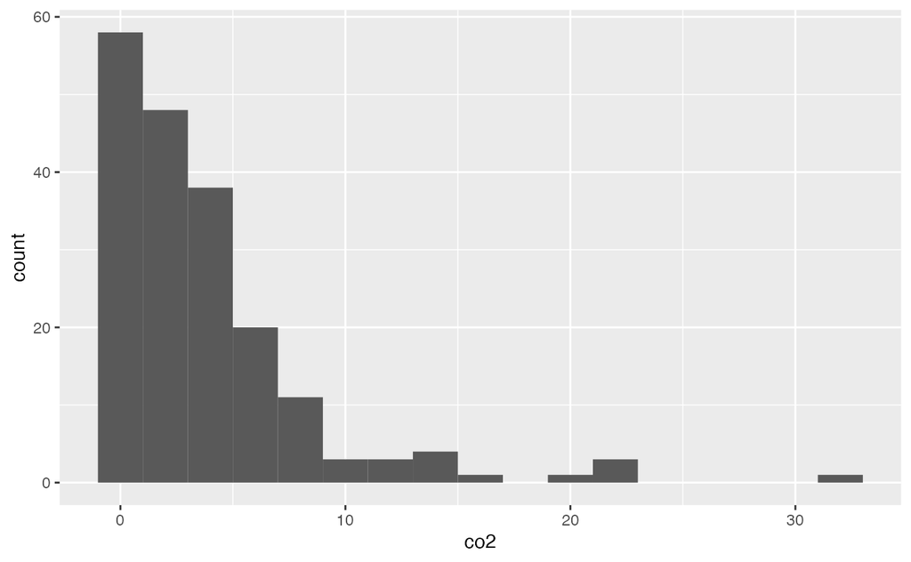

```r
df_co2fos |> filter(!(iso2c %in% REGION)) |> filter(year == 2020) |> drop_na(co2) |>
  ggplot(aes(co2)) + geom_histogram(binwidth = 2)
```

これに地域名を加えることも可能です。

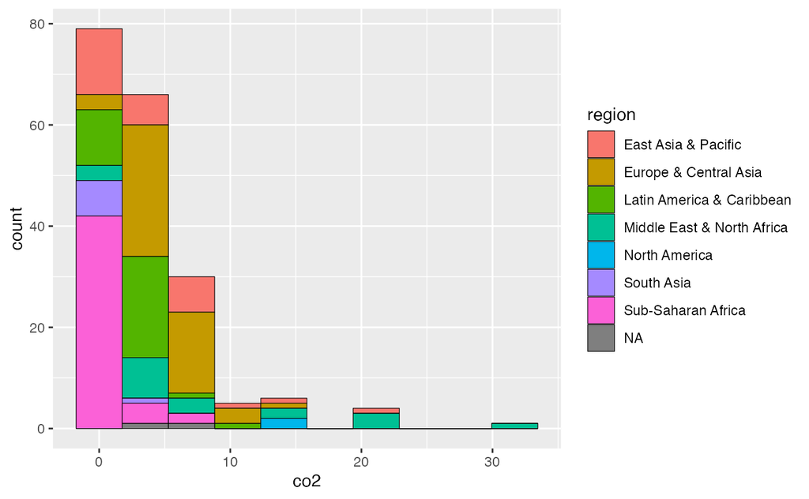

```r
df_co2fos |> filter(!(iso2c %in% REGION)) |> filter(year == 2020) |> drop_na(co2) |>
  ggplot(aes(co2, fill = region)) + geom_histogram(bins = 10, col = "black", linewidth = 0.2)
```

左に偏っているので、LOG 表示を使うこともひとつです。

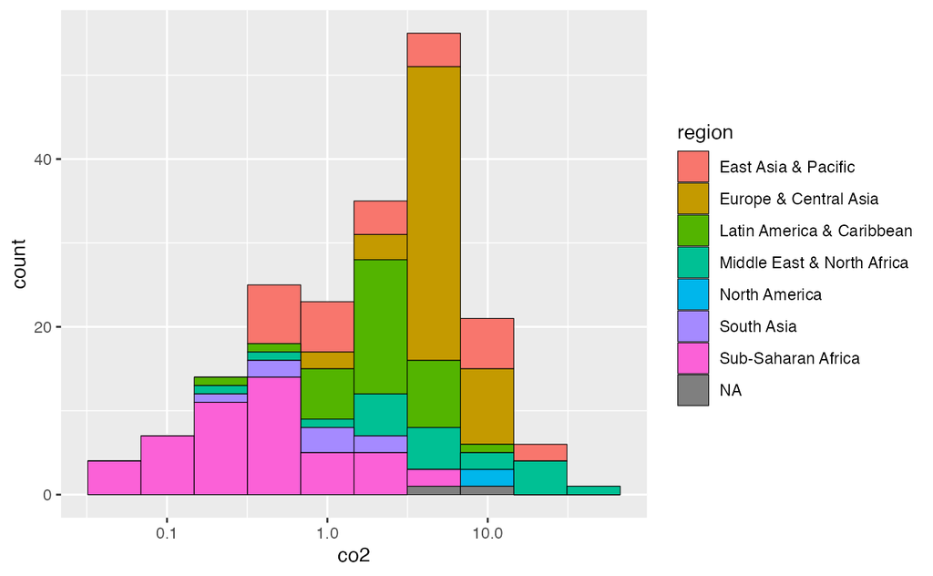

```r
df_co2fos |> filter(!(iso2c %in% REGION)) |> filter(year == 2020) |> drop_na(co2) |>
  ggplot(aes(co2, fill = region)) +
  geom_histogram(bins = 10, col = "black", linewidth = 0.2) + scale_x_log10()
```

もう一つの変数、fossil についてもやってみてください。

### 5.3.2 棒グラフ

カテゴリー変数（日本語では名目変数ということばも使われます）と、その値が与えられているときに使います。データの数の時に使った、geom_bar も似ていますが、こちらは、カテゴリー変数や飛び飛びの値（discrete numerical variable）の数値変数などの、数を数えます。

#### 5.3.2.1 例

データが十分ある最近の年の値の10カ国の値の棒グラフ

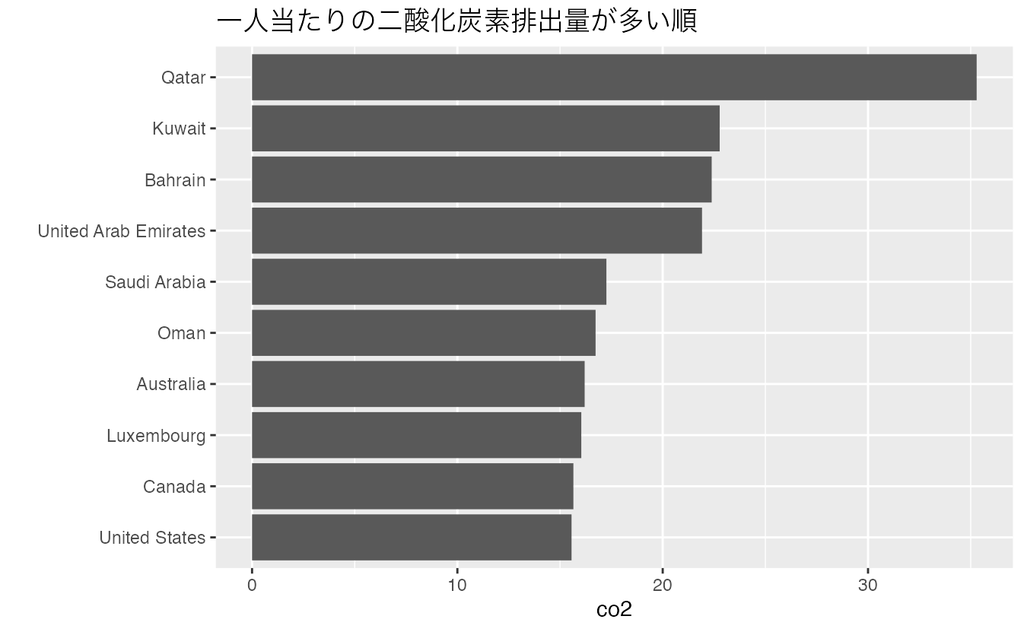

```r
df_co2fos |> filter(!(iso2c %in% REGION)) |> filter(year == 2015) |> drop_na(co2) |>
  arrange(desc(co2)) |> slice_head(n = 10) |>
  ggplot(aes(fct_rev(fct_inorder(country)), co2)) + geom_col() + coord_flip() + labs(title = "一人当たりの二酸化炭素排出量が多い順", x = "")
```

地域ことに色分けすることも可能です。

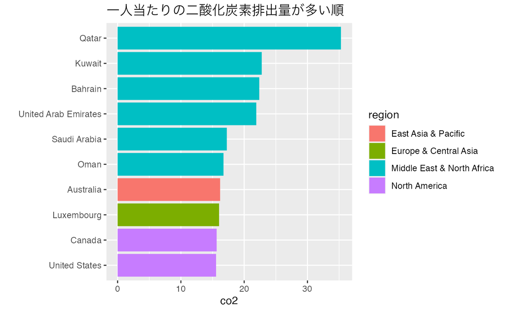

```r
df_co2fos |> filter(!(iso2c %in% REGION)) |> filter(year == 2015) |> drop_na(co2) |>
  arrange(desc(co2)) |> slice_head(n = 10) |>
  ggplot(aes(fct_rev(fct_inorder(country)), co2, fill = region)) + geom_col() + coord_flip() + labs(title = "一人当たりの二酸化炭素排出量が多い順", x = "")
```

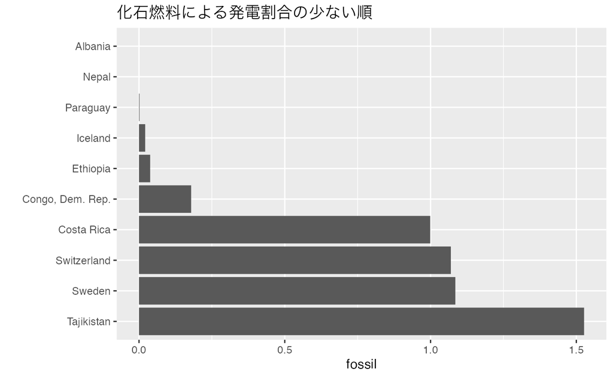

```r
df_co2fos |> filter(!(iso2c %in% REGION)) |> filter(year == 2015) |> drop_na(fossil) |>
  arrange(fossil) |> slice_head(n = 10) |>
  ggplot(aes(fct_rev(fct_inorder(country)), fossil)) + geom_col() + coord_flip()  + labs(title = "化石燃料による発電割合の少ない順", x = "")
```

所得レベルで色分けをしてみましょう。

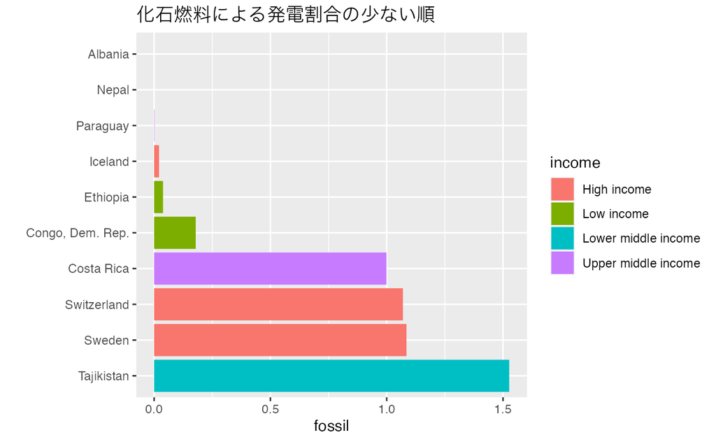

```r
df_co2fos |> filter(!(iso2c %in% REGION)) |> filter(year == 2015) |> drop_na(fossil) |>
  arrange(fossil) |> slice_head(n = 10) |>
  ggplot(aes(fct_rev(fct_inorder(country)), fossil, fill = income)) + geom_col() + coord_flip()  + labs(title = "化石燃料による発電割合の少ない順", x = "")
```

### 5.3.3 箱ひげ図（Boxplot）

カテゴリ変数（country, region, income など）毎の分布を描く

- `ggplot(aes(categorical_var, numerical_var)) + geom_boxplot()`
- `ggplot(aes(region, electricity_urban)) + geom_boxplot()`
- `ggplot(aes(income, electricity_rural)) + geom_boxplot()`
- `pivot_longer(cols = c(var1, var2)) |> ggplot(aes(name, value)) + geom_boxplot()`
- year は、整数なので数値変数（numerical variable）。これを カテゴリー変数として扱うためには、`factor(yea`r) を使う。`x` 軸のラベルなどはあとから修正が必要。
  - `filter(year %in% c(1960,1990,2020))|> ggplot(aes(factor(year), var)) + geom_boxplot()`

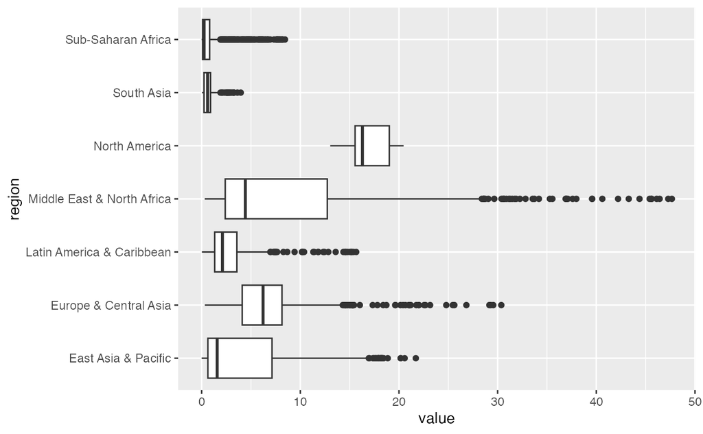

```r
df_co2fos_long |> filter(name == "co2") |>
  filter(region != "Aggregates") |> drop_na(value) |>
  ggplot(aes(region, value)) + geom_boxplot() + coord_flip()
```

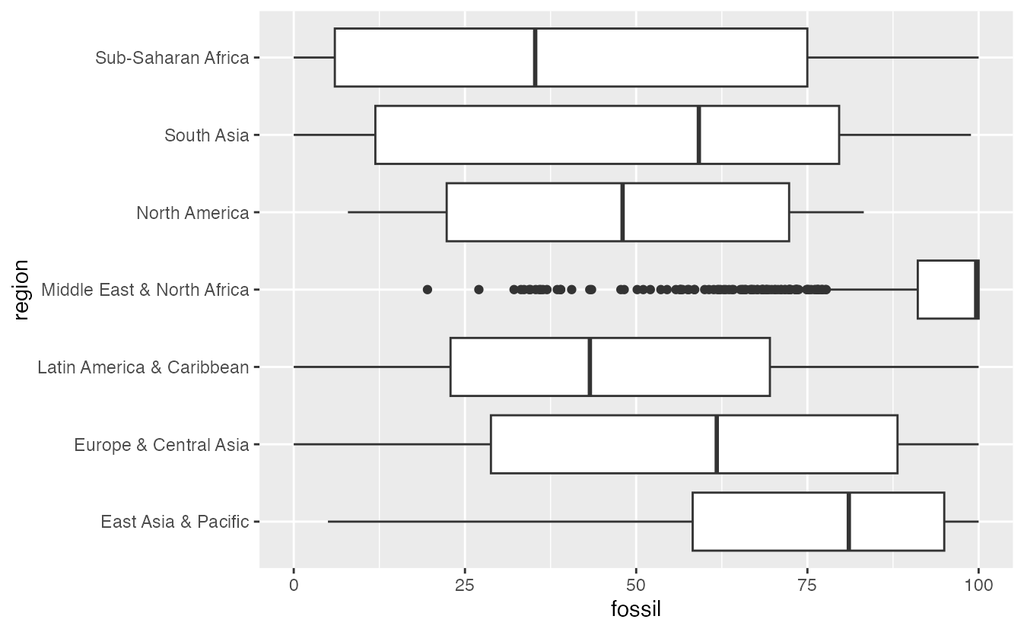

```r
df_co2fos |> filter(region != "Aggregates") |> drop_na(fossil) |>
  ggplot(aes(region, fossil)) + geom_boxplot() + coord_flip()
```

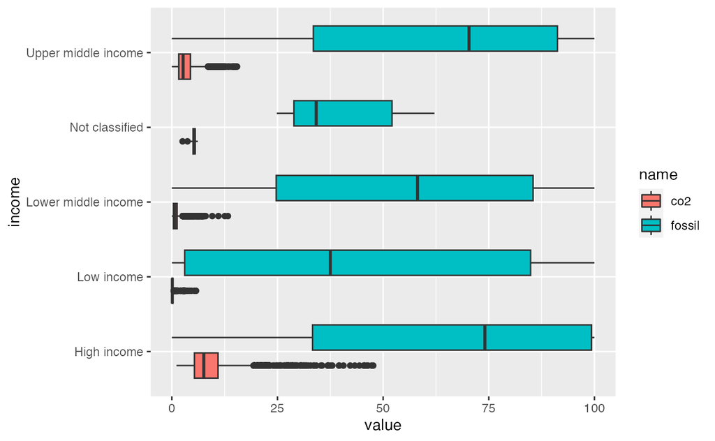

```r
df_co2fos_long |>
  filter(income != "Aggregates") |> drop_na(value) |>
  ggplot(aes(income, value, fill = name)) + geom_boxplot() + coord_flip()
```

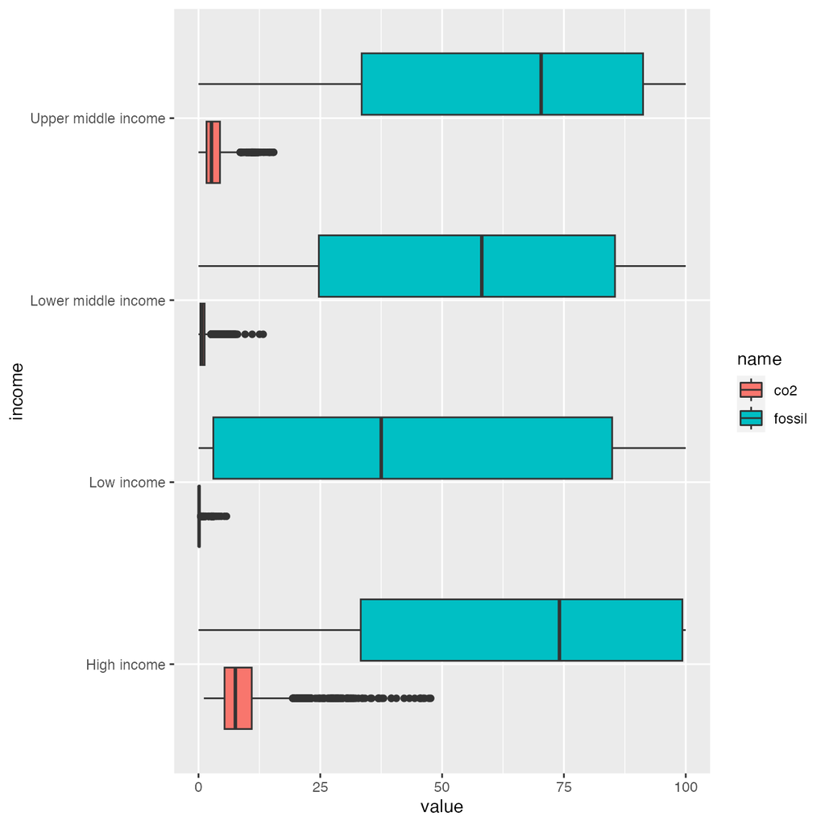

```r
df_co2fos_long |> filter(income != "Aggregates", income != "Not classified") |> drop_na(value) |>
  ggplot(aes(income, value, fill = name)) + geom_boxplot() + coord_flip()
```

## 5.4 相関

### 5.4.1 相関係数

値の正負：正の相関・負の相関、1に近いと強い正の相関、-1に近いと強い負の相関

相関係数：散布図の近似（回帰）直線の傾きが正なら正、負なら負、直線に近い程、1 または-1 に近い

あくまでも、相関であり、因果関係ではない。再生可能エネルギーを増やしたり、化石燃料による発電を減らしたり、森を増やせば、二酸化炭素排出量が減ると、ここから結論できるわけではない。あくまでも、化石燃料の発電が多い国のほうが、二酸化炭素排出量が多い傾向があるというようなことが見て取れることである。相関関係は因果関係にあらず。Correlation is not causation.

#### 5.4.1.1 例

変数同士の相関関係: NA ではないところのみ選択します。

```r
df_co2fos |> filter(!(iso2c %in% REGION)) |> # 地域以外（国のみ選択）
  drop_na(co2, fossil) |>
  select(co2, fossil) |> cor()
```

[output not shown]

これは、弱い正の相関となります。つまり、「化石燃料による発電が多い国はある程度、二酸化炭素排出量が多い傾向にある」と言えます。

### 5.4.2 エラー対応

- 入力したときには、例を参照して、スペルを確認。全角や変数名の空白は問題を起こす。括弧 () や引用符がペアでマッチしているか、確認。引用符が入っていなかったり、== のところが、= だったり、Error は様々。
- File not found のときは、データを読み込むコードを再実行。それでもうまくいかないときは、data フォルダに、データ（***.csv）が入っているかを確認、なければ、data フォルダがあることを確認、なければ作成して読み込みを実行。
- Object not found のエラーがでたときには、上から順に、Run （Code Chunk の右上の三角印を押して実行）。または、エラー箇所にカーソルを置き、Run ボタンの右の三角から、Run All Chunks Above を選択して実行。
- 実行できていても、結果が見えないことがある。そのときは、Code Chunk の下にある、山二つの記号を押す。結果の表示、非表示の切り替え。
- Error message を読む。エラーが出た Code Chunk と、Error message を、ChatGPT や、Google Bard, Google Search に入れ解決方法を探る。
- Posit.Cloud で、Error 137 が出た時はメモリーオーバーなので、例など不要な部分を削除。ただし、一番上の、YAML は、かならず残すこと。

### 5.4.3 散布図

基本形は、次のようになります。

```
df_co2fos |> filter で選択 |> drop_na(変数1, 変数2) |>
  ggplot(aes(変数1, 変数2)) + geom_point()
```

#### 5.4.3.1 例

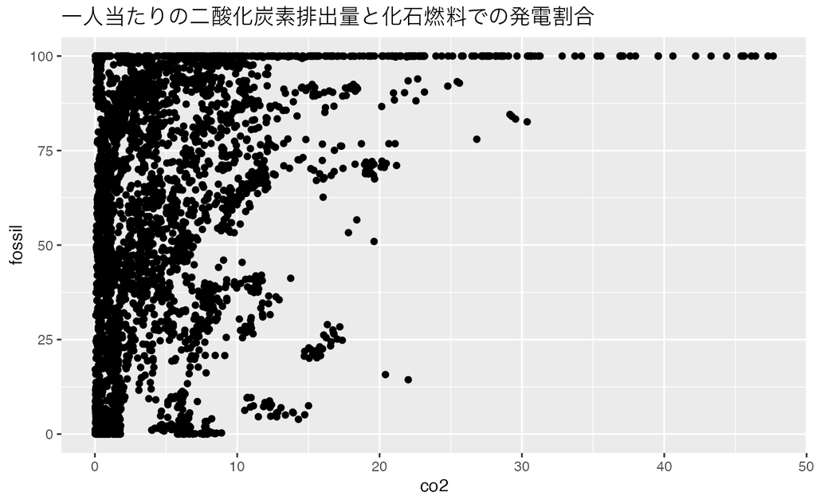

```r
df_co2fos |> filter(!(iso2c %in% REGION)) |> drop_na(co2, fossil) |>
  ggplot(aes(co2, fossil)) + geom_point() +
  labs(title = "一人当たりの二酸化炭素排出量と化石燃料での発電割合")
```

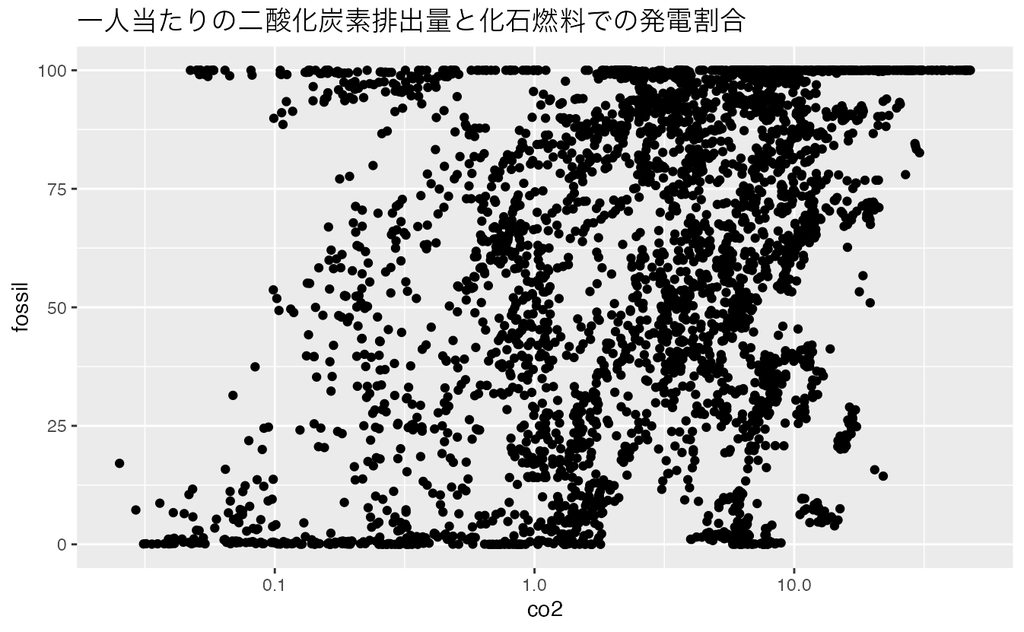

```r
df_co2fos |> filter(!(iso2c %in% REGION)) |> drop_na(co2, fossil) |>
  ggplot(aes(co2, fossil)) + geom_point() + scale_x_log10() +
  labs(title = "一人当たりの二酸化炭素排出量と化石燃料での発電割合")
```

## 5.5 参考文献

- 課題1：解説 [リンク](https://ds-sl.github.io/intro2r/ges001/w5a_response.nb.html)・解答例 [リンク](https://ds-sl.github.io/intro2r/ges001/w5eda0.nb.html)
- 第6週演習：解答例 [リンク](https://ds-sl.github.io/intro2r/ges001/w6eda0.nb.html)
1. 「みんなのデータサイエンス - Data Science for All」[[はじめてのデータサイエンス](https://icu-hsuzuki.github.io/ds4aj/first-example.html#first-example)]
2. Posit Recipes（旧 Posit Primers）: The Basics 対話型の演習サイトの最初 [[Link](https://posit.cloud/learn/recipes)]
3. Posit Cheat Sheet. 早見表です。印刷して使うために、PDF も提供しています。[[Site Link](https://rstudio.github.io/cheatsheets/)]
4. DataCamp Cheat Sheet: Tidyverse for Biginners. データサイエンスの教育をしている会社の早見表の一つです。基本が簡単にまとまっています。[[Link](https://images.datacamp.com/image/upload/v1676302697/Marketing/Blog/Tidyverse_Cheat_Sheet.pdf)]
5. 箱ひげ図の見方 [Link](https://bellcurve.jp/statistics/course/5220.html)、外れ値検出のある箱ひげ図 [Link](https://bellcurve.jp/statistics/course/5222.html)
6. Video: [Histogram](https://vimeo.com/221607341), [Boxplot](https://vimeo.com/222358034)